# Peter Oropeza's Test for Kinedu

## Importar las librerias principales

```python
import pandas as pd
import numpy as np
import matplotlib.pyplot as plt
import pandas_profiling
```

### Lectura inicial de archivos

```python
stations = pd.read_csv('stations.csv',sep=',')
```

```python
stations.head()
```

|  | id | lat | lon | name |
| --- | --- | --- | --- | --- |
| 0 | 1 | 19.433571 | -99.167809 | 1 RIO SENA-RIO BALSAS |
| 1 | 2 | 19.431386 | -99.171695 | 2 RIO GUADALQUIVIR-RIO BALSAS |
| 2 | 3 | 19.431655 | -99.158668 | 3 REFORMA-INSURGENTES |
| 3 | 4 | 19.428309 | -99.171713 | 4 RIO NILO-RIO PANUCO |
| 4 | 5 | 19.429720 | -99.169363 | 5 RIO PANUCO-RIO TIBER |

```python
stations.describe()
```

|  | id | lat | lon |
| --- | --- | --- | --- |
| count | 480.000000 | 480.000000 | 480.000000 |
| mean | 240.500000 | 19.409647 | -99.170918 |
| std | 138.708327 | 0.024425 | 0.015825 |
| min | 1.000000 | 19.358270 | -99.212845 |
| 25% | 120.750000 | 19.388946 | -99.179836 |
| 50% | 240.500000 | 19.414846 | -99.171091 |
| 75% | 360.250000 | 19.430649 | -99.160599 |
| max | 480.000000 | 19.446073 | -99.130918 |

```python
stations[stations['name'] == '5 RIO PANUCO-RIO TIBER']
```

|  | id | lat | lon | name |
| --- | --- | --- | --- | --- |
| 4 | 5 | 19.42972 | -99.169363 | 5 RIO PANUCO-RIO TIBER |

```python
agosto = pd.read_csv('2019-08.csv',sep=',')
```

```python
agosto.head()
```

|  | Genero_Usuario | Edad_Usuario | Bici | Ciclo_Estacion_Retiro | Fecha_Retiro | Hora_Retiro | Ciclo_Estacion_Arribo | Fecha_Arribo | Hora_Arribo |
| --- | --- | --- | --- | --- | --- | --- | --- | --- | --- |
| 0 | M | 24 | 8256 | 52 | 01/08/2019 | 0:00:18 | 269 | 01/08/2019 | 0:07:30 |
| 1 | M | 26 | 9439 | 125 | 01/08/2019 | 0:00:34 | 127 | 01/08/2019 | 0:10:03 |
| 2 | M | 26 | 12414 | 34 | 01/08/2019 | 0:02:27 | 59 | 01/08/2019 | 0:10:26 |
| 3 | M | 38 | 15048 | 108 | 01/08/2019 | 0:03:13 | 260 | 01/08/2019 | 0:07:42 |
| 4 | F | 32 | 2404 | 133 | 01/08/2019 | 0:06:45 | 465 | 01/08/2019 | 0:53:20 |

```python
agosto.describe()
```

|  | Edad_Usuario | Bici | Ciclo_Estacion_Retiro | Ciclo_Estacion_Arribo |
| --- | --- | --- | --- | --- |
| count | 748705.000000 | 748705.000000 | 748705.000000 | 748705.00000 |
| mean | 35.068983 | 9199.430523 | 185.007367 | 182.26505 |
| std | 10.350310 | 2727.233879 | 133.209728 | 133.23572 |
| min | 16.000000 | 859.000000 | 1.000000 | 1.00000 |
| 25% | 28.000000 | 7726.000000 | 66.000000 | 64.00000 |
| 50% | 32.000000 | 9409.000000 | 165.000000 | 158.00000 |
| 75% | 40.000000 | 11201.000000 | 278.000000 | 274.00000 |
| max | 97.000000 | 15339.000000 | 3001.000000 | 3001.00000 |

```python
agosto.dtypes
```

```
Genero_Usuario           object
Edad_Usuario              int64
Bici                      int64
Ciclo_Estacion_Retiro     int64
Fecha_Retiro             object
Hora_Retiro              object
Ciclo_Estacion_Arribo     int64
Fecha_Arribo             object
Hora_Arribo              object
dtype: object
```

### Reviso si existe algún dato faltante

```python
missing_values_count = agosto.isnull().sum()
print(missing_values_count)
```

```
Genero_Usuario           0
Edad_Usuario             0
Bici                     0
Ciclo_Estacion_Retiro    0
Fecha_Retiro             0
Hora_Retiro              0
Ciclo_Estacion_Arribo    0
Fecha_Arribo             0
Hora_Arribo              0
dtype: int64
```

```python
septiembre = pd.read_csv('2019-09.csv',sep=',')
```

```python
septiembre.dtypes
```

```
Genero_Usuario           object
Edad_Usuario              int64
Bici                      int64
Ciclo_Estacion_Retiro     int64
Fecha_Retiro             object
Hora_Retiro              object
Ciclo_Estacion_Arribo     int64
Fecha_Arribo             object
Hora_Arribo              object
dtype: object
```

```python
missing_values_count = septiembre.isnull().sum()
print(missing_values_count)
```

```
Genero_Usuario           0
Edad_Usuario             0
Bici                     0
Ciclo_Estacion_Retiro    0
Fecha_Retiro             0
Hora_Retiro              0
Ciclo_Estacion_Arribo    0
Fecha_Arribo             0
Hora_Arribo              0
dtype: int64
```

```python
octubre = pd.read_csv('2019-10.csv',sep=',')
```

### En este punto existe una inconsistencia en los tipos de datos

```python
octubre.head()
```

|  | Genero_Usuario | Edad_Usuario | Bici | Ciclo_Estacion_Retiro | Fecha_Retiro | Hora_Retiro | Ciclo_Estacion_Arribo | Fecha_Arribo | Hora_Arribo |
| --- | --- | --- | --- | --- | --- | --- | --- | --- | --- |
| 0 | M | 22 | 7639 | 51 | 01/10/2019 | 00:00:18 | 2 | 01/10/2019 | 00:08:05 |
| 1 | M | 29 | 10638 | 164 | 01/10/2019 | 00:00:27 | 258 | 01/10/2019 | 00:11:05 |
| 2 | M | 21 | 8682 | 115 | 01/10/2019 | 00:00:40 | 265 | 01/10/2019 | 00:07:48 |
| 3 | M | 43 | 8005 | 137 | 01/10/2019 | 00:01:43 | 56 | 01/10/2019 | 00:05:28 |
| 4 | M | 59 | 11943 | 174 | 01/10/2019 | 00:02:56 | 183 | 01/10/2019 | 00:06:16 |

```python
octubre.dtypes
```

```
Genero_Usuario           object
Edad_Usuario              int64
Bici                     object
Ciclo_Estacion_Retiro     int64
Fecha_Retiro             object
Hora_Retiro              object
Ciclo_Estacion_Arribo     int64
Fecha_Arribo             object
Hora_Arribo              object
dtype: object
```

```python
missing_values_count = octubre.isnull().sum()
print(missing_values_count)
```

```
Genero_Usuario           0
Edad_Usuario             0
Bici                     0
Ciclo_Estacion_Retiro    0
Fecha_Retiro             0
Hora_Retiro              0
Ciclo_Estacion_Arribo    0
Fecha_Arribo             0
Hora_Arribo              0
dtype: int64
```

### La inconsistencia encontrada fue en la columna 'Bici', ya que en el mes de agosto y septiembre se considera como int64 y en octubre se considera como objeto

```python
octubre['Bici'].map(type)
```

```
0         <class 'int'>
1         <class 'int'>
2         <class 'int'>
3         <class 'int'>
4         <class 'int'>
              ...
740994    <class 'str'>
740995    <class 'str'>
740996    <class 'str'>
740997    <class 'str'>
740998    <class 'str'>
Name: Bici, Length: 740999, dtype: object
```

### Se realiza un mapeo de tipos de datos para columna 'Bici' y ver de qué se encuentra compuesto. En este caso, se consiguió los tipos de datos int y str

```python
octubre[octubre['Bici'].map(type) != str]
```

|  | Genero_Usuario | Edad_Usuario | Bici | Ciclo_Estacion_Retiro | Fecha_Retiro | Hora_Retiro | Ciclo_Estacion_Arribo | Fecha_Arribo | Hora_Arribo |
| --- | --- | --- | --- | --- | --- | --- | --- | --- | --- |
| 0 | M | 22 | 7639 | 51 | 01/10/2019 | 00:00:18 | 2 | 01/10/2019 | 00:08:05 |
| 1 | M | 29 | 10638 | 164 | 01/10/2019 | 00:00:27 | 258 | 01/10/2019 | 00:11:05 |
| 2 | M | 21 | 8682 | 115 | 01/10/2019 | 00:00:40 | 265 | 01/10/2019 | 00:07:48 |
| 3 | M | 43 | 8005 | 137 | 01/10/2019 | 00:01:43 | 56 | 01/10/2019 | 00:05:28 |
| 4 | M | 59 | 11943 | 174 | 01/10/2019 | 00:02:56 | 183 | 01/10/2019 | 00:06:16 |
| ... | ... | ... | ... | ... | ... | ... | ... | ... | ... |
| 655355 | M | 57 | 11192 | 46 | 28/10/2019 | 19:53:18 | 217 | 28/10/2019 | 20:05:56 |
| 655356 | M | 25 | 10340 | 151 | 28/10/2019 | 19:53:21 | 134 | 28/10/2019 | 19:58:50 |
| 655357 | M | 31 | 2182 | 22 | 28/10/2019 | 19:53:22 | 29 | 28/10/2019 | 20:09:07 |
| 655358 | M | 29 | 11661 | 357 | 28/10/2019 | 19:53:23 | 341 | 28/10/2019 | 20:01:25 |
| 655359 | M | 22 | 7389 | 52 | 28/10/2019 | 19:53:29 | 52 | 28/10/2019 | 19:57:08 |

589824 rows × 9 columns

```python
octubre[octubre['Bici'].str.match('[A-Za-z_]') == True]
```

|  | Genero_Usuario | Edad_Usuario | Bici | Ciclo_Estacion_Retiro | Fecha_Retiro | Hora_Retiro | Ciclo_Estacion_Arribo | Fecha_Arribo | Hora_Arribo |
| --- | --- | --- | --- | --- | --- | --- | --- | --- | --- |
| 352754 | M | 39 | lab003 | 1001 | 15/10/2019 | 12:12:59 | 1001 | 15/10/2019 | 12:16:37 |
| 352768 | M | 39 | f2009 | 1001 | 15/10/2019 | 12:14:16 | 1001 | 15/10/2019 | 12:22:12 |
| 352872 | M | 59 | f2002 | 1001 | 15/10/2019 | 12:19:34 | 1001 | 15/10/2019 | 12:22:08 |
| 672979 | M | 59 | f2009 | 1001 | 29/10/2019 | 14:17:10 | 1001 | 29/10/2019 | 14:19:44 |
| 673121 | M | 59 | f2002 | 1001 | 29/10/2019 | 14:21:13 | 1001 | 29/10/2019 | 14:37:58 |
| 674339 | M | 59 | f2002 | 1001 | 29/10/2019 | 15:02:25 | 1001 | 29/10/2019 | 15:04:41 |
| 702125 | M | 59 | f2009 | 1001 | 30/10/2019 | 13:39:34 | 1001 | 30/10/2019 | 13:43:50 |
| 702481 | M | 59 | f2009 | 1001 | 30/10/2019 | 13:53:08 | 1001 | 30/10/2019 | 13:57:41 |
| 702619 | M | 59 | f2009 | 1001 | 30/10/2019 | 13:58:10 | 1001 | 30/10/2019 | 14:02:46 |
| 703725 | M | 59 | f2009 | 1001 | 30/10/2019 | 14:32:01 | 1001 | 30/10/2019 | 15:59:52 |
| 707588 | M | 59 | lab003 | 1001 | 30/10/2019 | 16:57:27 | 1001 | 30/10/2019 | 17:00:48 |
| 713618 | M | 59 | f2002 | 1001 | 29/10/2019 | 15:05:58 | 1001 | 30/10/2019 | 11:38:59 |
| 740936 | M | 59 | lab003 | 1001 | 30/10/2019 | 17:00:55 | 1001 | 31/10/2019 | 09:23:54 |

### Volvemos a leer agosto, septiembre y occtubre pero especificando los tipos de datos y Bici con str

```python
agosto = pd.read_csv('2019-08.csv',low_memory=False,sep=',',
dtype=
{
        'Genero_Usuario': 'object',
        'Edad_Usuario': 'int64',
        'Bici': 'str',
        'Ciclo_Estacion_Retiro': 'int64',
        'Fecha_Retiro': 'object',
        'Hora_Retiro': 'object',
        'Ciclo_Estacion_Arribo': 'int64',
        'Fecha_Arribo': 'object',
        'Hora_Arribo': 'object'
}
)
```

```python
agosto.dtypes
```

```
Genero_Usuario           object
Edad_Usuario              int64
Bici                     object
Ciclo_Estacion_Retiro     int64
Fecha_Retiro             object
Hora_Retiro              object
Ciclo_Estacion_Arribo     int64
Fecha_Arribo             object
Hora_Arribo              object
dtype: object
```

```python
agosto['Bici'].map(type)
```

```
0         <class 'str'>
1         <class 'str'>
2         <class 'str'>
3         <class 'str'>
4         <class 'str'>
              ...
748700    <class 'str'>
748701    <class 'str'>
748702    <class 'str'>
748703    <class 'str'>
748704    <class 'str'>
Name: Bici, Length: 748705, dtype: object
```

```python
septiembre = pd.read_csv('2019-09.csv',low_memory=False,sep=',',
dtype=
{
        'Genero_Usuario': 'object',
        'Edad_Usuario': 'int64',
        'Bici': 'str',
        'Ciclo_Estacion_Retiro': 'int64',
        'Fecha_Retiro': 'object',
        'Hora_Retiro': 'object',
        'Ciclo_Estacion_Arribo': 'int64',
        'Fecha_Arribo': 'object',
        'Hora_Arribo': 'object'
}
)
```

```python
octubre = pd.read_csv('2019-10.csv',low_memory=False,sep=',',
dtype=
{
        'Genero_Usuario': 'object',
        'Edad_Usuario': 'int64',
        'Bici': 'str',
        'Ciclo_Estacion_Retiro': 'int64',
        'Fecha_Retiro': 'object',
        'Hora_Retiro': 'object',
        'Ciclo_Estacion_Arribo': 'int64',
        'Fecha_Arribo': 'object',
        'Hora_Arribo': 'object'
}
)
```

## Ya que hay consistencia en los datos, procederemos a juntar toda la info en un solo dataframe

```python
datos = [agosto, septiembre, octubre]
```

```python
viajes = pd.concat(datos)
```

```python
viajes['fechaI'] = pd.to_datetime(viajes['Fecha_Retiro'], format="%d/%m/%Y")
viajes['fechaF'] = pd.to_datetime(viajes['Fecha_Arribo'], format="%d/%m/%Y")

viajes['horaI'] = pd.to_datetime(viajes['Hora_Retiro'], format="%H:%M:%S")
viajes['horaF'] = pd.to_datetime(viajes['Hora_Arribo'], format="%H:%M:%S")
```

## Agregamos el tipo de dato de fecha y hora a las columnas correspondientes

```python
viajes.Fecha_Retiro=pd.to_datetime(viajes.Fecha_Retiro)
viajes.Hora_Arribo=pd.to_datetime(viajes.Hora_Arribo)
viajes.Hora_Retiro=pd.to_datetime(viajes.Hora_Retiro)
```

## Validamos que los datos se encuentren dentro de las fechas por analizar (agosto, septiembre y octubre de 2019)

```python
viajes[(viajes['Fecha_Retiro'] < '2019-08-01') |
(viajes['Fecha_Retiro'] > '2019-10-31')]
```

|  | Genero_Usuario | Edad_Usuario | Bici | Ciclo_Estacion_Retiro | Fecha_Retiro | Hora_Retiro | Ciclo_Estacion_Arribo | Fecha_Arribo | Hora_Arribo | fechaI | fechaF | horaI | horaF |
| --- | --- | --- | --- | --- | --- | --- | --- | --- | --- | --- | --- | --- | --- |
| 0 | M | 24 | 8256 | 52 | 2019-01-08 | 2021-05-26 00:00:18 | 269 | 01/08/2019 | 2021-05-26 00:07:30 | 2019-08-01 | 2019-08-01 | 1900-01-01 00:00:18 | 1900-01-01 00:07:30 |
| 1 | M | 26 | 9439 | 125 | 2019-01-08 | 2021-05-26 00:00:34 | 127 | 01/08/2019 | 2021-05-26 00:10:03 | 2019-08-01 | 2019-08-01 | 1900-01-01 00:00:34 | 1900-01-01 00:10:03 |
| 2 | M | 26 | 12414 | 34 | 2019-01-08 | 2021-05-26 00:02:27 | 59 | 01/08/2019 | 2021-05-26 00:10:26 | 2019-08-01 | 2019-08-01 | 1900-01-01 00:02:27 | 1900-01-01 00:10:26 |
| 3 | M | 38 | 15048 | 108 | 2019-01-08 | 2021-05-26 00:03:13 | 260 | 01/08/2019 | 2021-05-26 00:07:42 | 2019-08-01 | 2019-08-01 | 1900-01-01 00:03:13 | 1900-01-01 00:07:42 |
| 4 | F | 32 | 2404 | 133 | 2019-01-08 | 2021-05-26 00:06:45 | 465 | 01/08/2019 | 2021-05-26 00:53:20 | 2019-08-01 | 2019-08-01 | 1900-01-01 00:06:45 | 1900-01-01 00:53:20 |
| ... | ... | ... | ... | ... | ... | ... | ... | ... | ... | ... | ... | ... | ... |
| 311178 | M | 28 | 10456 | 271 | 2019-12-10 | 2021-05-26 23:59:53 | 145 | 13/10/2019 | 2021-05-26 00:15:24 | 2019-10-12 | 2019-10-13 | 1900-01-01 23:59:53 | 1900-01-01 00:15:24 |
| 340949 | F | 43 | 10887 | 329 | 2019-12-10 | 2021-05-26 12:34:34 | 14 | 14/10/2019 | 2021-05-26 15:28:07 | 2019-10-12 | 2019-10-14 | 1900-01-01 12:34:34 | 1900-01-01 15:28:07 |
| 340950 | F | 34 | 9382 | 334 | 2019-12-10 | 2021-05-26 13:26:26 | 157 | 14/10/2019 | 2021-05-26 12:40:22 | 2019-10-12 | 2019-10-14 | 1900-01-01 13:26:26 | 1900-01-01 12:40:22 |
| 340951 | M | 29 | 7361 | 306 | 2019-12-10 | 2021-05-26 17:44:56 | 368 | 14/10/2019 | 2021-05-26 00:00:07 | 2019-10-12 | 2019-10-14 | 1900-01-01 17:44:56 | 1900-01-01 00:00:07 |
| 688790 | M | 23 | 7201 | 330 | 2019-03-10 | 2021-05-26 08:48:44 | 3002 | 29/10/2019 | 2021-05-26 14:01:53 | 2019-10-03 | 2019-10-29 | 1900-01-01 08:48:44 | 1900-01-01 14:01:53 |

644805 rows × 13 columns

```python
viajes = viajes[(viajes['Fecha_Retiro'] >= '2019-08-01') &
(viajes['Fecha_Retiro'] <= '2019-10-31')]
```

### Reviso si existen filas duplicadas

```python
viajes[viajes.duplicated()==True] #no hay duplicados
```

|  | Genero_Usuario | Edad_Usuario | Bici | Ciclo_Estacion_Retiro | Fecha_Retiro | Hora_Retiro | Ciclo_Estacion_Arribo | Fecha_Arribo | Hora_Arribo | fechaI | fechaF | horaI | horaF |
| --- | --- | --- | --- | --- | --- | --- | --- | --- | --- | --- | --- | --- | --- |

```python
estacionesF = viajes.groupby(['Ciclo_Estacion_Arribo'])
```

```python
cantF = estacionesF['Ciclo_Estacion_Arribo'].count()
```

# Estación de arribo con menos bici drop

```python
cantF[estacionesF['Ciclo_Estacion_Arribo'].count()==cantF.min()]
```

```
Ciclo_Estacion_Arribo
3001    3
Name: Ciclo_Estacion_Arribo, dtype: int64
```

# Estación de arribo con más bici drop

```python
cantF[estacionesF['Ciclo_Estacion_Arribo'].count()==cantF.max()]
```

```
Ciclo_Estacion_Arribo
266    17368
Name: Ciclo_Estacion_Arribo, dtype: int64
```

# Top 5 estaciones de arribo con más bici drop

```python
cantF.sort_values(ascending=False).head(5) #top5
```

```
Ciclo_Estacion_Arribo
266    17368
27     13843
1      13688
271    11146
64     10912
Name: Ciclo_Estacion_Arribo, dtype: int64
```

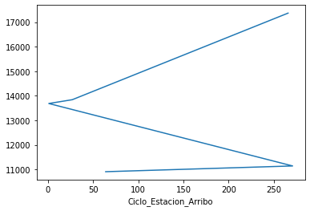

```python
cantF.sort_values(ascending=False).head(5).plot()
```

# Top 5 estaciones de arribo con menos bici drop

```python
cantF.sort_values(ascending=True).head(5) #bottom5
```

```
Ciclo_Estacion_Arribo
3001      3
3002      6
1001     13
3000     18
1002    130
Name: Ciclo_Estacion_Arribo, dtype: int64
```

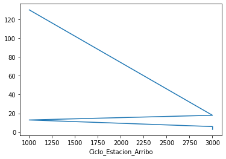

```python
cantF.sort_values(ascending=True).head(5).plot()
```

# Ahora buscamos las horas pico

```python
tt = viajes.groupby([pd.Grouper(key='Hora_Arribo',freq='H'),viajes.Ciclo_Estacion_Arribo]).size().reset_index(name='count')
```

```python
tt
```

|  | Hora_Arribo | Ciclo_Estacion_Arribo | count |
| --- | --- | --- | --- |
| 0 | 2021-05-26 00:00:00 | 1 | 95 |
| 1 | 2021-05-26 00:00:00 | 2 | 40 |
| 2 | 2021-05-26 00:00:00 | 3 | 4 |
| 3 | 2021-05-26 00:00:00 | 4 | 20 |
| 4 | 2021-05-26 00:00:00 | 5 | 32 |
| ... | ... | ... | ... |
| 10418 | 2021-05-26 23:00:00 | 476 | 50 |
| 10419 | 2021-05-26 23:00:00 | 477 | 8 |
| 10420 | 2021-05-26 23:00:00 | 478 | 35 |
| 10421 | 2021-05-26 23:00:00 | 479 | 7 |
| 10422 | 2021-05-26 23:00:00 | 480 | 36 |

10423 rows × 3 columns

# Hora pico de arribo de bicicletas

```python
tt.sort_values(ascending=False, by=['count']).head(5)
```

|  | Hora_Arribo | Ciclo_Estacion_Arribo | count |
| --- | --- | --- | --- |
| 8304 | 2021-05-26 19:00:00 | 266 | 3818 |
| 7826 | 2021-05-26 18:00:00 | 266 | 3056 |
| 7827 | 2021-05-26 18:00:00 | 267 | 2865 |
| 8305 | 2021-05-26 19:00:00 | 267 | 2719 |
| 7346 | 2021-05-26 17:00:00 | 266 | 2569 |

```python
ff = viajes.groupby([pd.Grouper(key='Hora_Retiro',freq='H'),viajes.Ciclo_Estacion_Retiro]).size().reset_index(name='count')
```

```python
ff
```

|  | Hora_Retiro | Ciclo_Estacion_Retiro | count |
| --- | --- | --- | --- |
| 0 | 2021-05-26 00:00:00 | 1 | 15 |
| 1 | 2021-05-26 00:00:00 | 2 | 3 |
| 2 | 2021-05-26 00:00:00 | 3 | 5 |
| 3 | 2021-05-26 00:00:00 | 4 | 18 |
| 4 | 2021-05-26 00:00:00 | 5 | 23 |
| ... | ... | ... | ... |
| 9989 | 2021-05-26 23:00:00 | 476 | 15 |
| 9990 | 2021-05-26 23:00:00 | 477 | 11 |
| 9991 | 2021-05-26 23:00:00 | 478 | 4 |
| 9992 | 2021-05-26 23:00:00 | 479 | 3 |
| 9993 | 2021-05-26 23:00:00 | 480 | 11 |

9994 rows × 3 columns

# Hora pico de retiro de bicicletas

```python
ff.sort_values(ascending=False, by=['count']).head(5)
```

|  | Hora_Retiro | Ciclo_Estacion_Retiro | count |
| --- | --- | --- | --- |
| 2624 | 2021-05-26 08:00:00 | 271 | 4655 |
| 2619 | 2021-05-26 08:00:00 | 266 | 3264 |
| 3101 | 2021-05-26 09:00:00 | 271 | 2785 |
| 3096 | 2021-05-26 09:00:00 | 266 | 2132 |
| 2143 | 2021-05-26 07:00:00 | 266 | 2025 |

# Ahora iremos viendo el incremento o decremento por estación a partir de los meses

```python
freqMes = viajes.groupby([pd.Grouper(key='Fecha_Retiro',freq='m'),viajes.Ciclo_Estacion_Retiro]).size().reset_index(name='count')
```

```python
freqMes
```

|  | Fecha_Retiro | Ciclo_Estacion_Retiro | count |
| --- | --- | --- | --- |
| 0 | 2019-08-31 | 1 | 4628 |
| 1 | 2019-08-31 | 2 | 1712 |
| 2 | 2019-08-31 | 3 | 1810 |
| 3 | 2019-08-31 | 4 | 1391 |
| 4 | 2019-08-31 | 5 | 1763 |
| ... | ... | ... | ... |
| 1432 | 2019-10-31 | 479 | 340 |
| 1433 | 2019-10-31 | 480 | 785 |
| 1434 | 2019-10-31 | 1001 | 13 |
| 1435 | 2019-10-31 | 3000 | 1 |
| 1436 | 2019-10-31 | 3002 | 3 |

1437 rows × 3 columns

```python
freqMes[freqMes['Ciclo_Estacion_Retiro']==3000]
```

|  | Fecha_Retiro | Ciclo_Estacion_Retiro | count |
| --- | --- | --- | --- |
| 955 | 2019-09-30 | 3000 | 5 |
| 1435 | 2019-10-31 | 3000 | 1 |

```python
freqMes['Incremento'] = freqMes.groupby(['Ciclo_Estacion_Retiro'])['count'].pct_change()
```

```python
freqMes[freqMes['Ciclo_Estacion_Retiro']==1]
```

|  | Fecha_Retiro | Ciclo_Estacion_Retiro | count | Incremento |
| --- | --- | --- | --- | --- |
| 0 | 2019-08-31 | 1 | 4628 | NaN |
| 478 | 2019-09-30 | 1 | 3994 | -0.136992 |
| 957 | 2019-10-31 | 1 | 4425 | 0.107912 |

# Top 3 de estaciones que han incrementado su demanda

```python
freqMes.sort_values(ascending=False, by=['Incremento']).head(3)
```

|  | Fecha_Retiro | Ciclo_Estacion_Retiro | count | Incremento |
| --- | --- | --- | --- | --- |
| 1199 | 2019-10-31 | 245 | 684 | 0.910615 |
| 1395 | 2019-10-31 | 441 | 227 | 0.669118 |
| 1365 | 2019-10-31 | 411 | 173 | 0.572727 |

# Top 3 de estaciones que han descrementado su demanda

```python
freqMes.sort_values(ascending=True, by=['Incremento']).head(3)
```

|  | Fecha_Retiro | Ciclo_Estacion_Retiro | count | Incremento |
| --- | --- | --- | --- | --- |
| 1358 | 2019-10-31 | 404 | 56 | -0.908943 |
| 494 | 2019-09-30 | 17 | 338 | -0.822012 |
| 1435 | 2019-10-31 | 3000 | 1 | -0.800000 |

#### Recordando que la función pct_change() lo que hace es calcular el incremento o decremento referente al mes previo el cálculo es: %actual=(demanda_actual-demanda_previa)/demanda_previa para el uso adecuado de dicha función, es necesario agrupar los datos por estación de bicicleta para que quedaran ordenados por mes. La elección de esta metodología fue debido a sus breves cálculos necesarios para su resultado y es una función ya definida y optimizada en la librería de pandas

# Relación entre retiros y arribos entre estaciones

## Cantidad de usuarios por genéro y mes

```python
viajes.groupby([pd.Grouper(key='Fecha_Retiro',freq='m'),viajes.Genero_Usuario]).size().reset_index(name='count')
```

|  | Fecha_Retiro | Genero_Usuario | count |
| --- | --- | --- | --- |
| 0 | 2019-08-31 | F | 139890 |
| 1 | 2019-08-31 | M | 412968 |
| 2 | 2019-09-30 | F | 115410 |
| 3 | 2019-09-30 | M | 338583 |
| 4 | 2019-10-31 | F | 128703 |
| 5 | 2019-10-31 | M | 383165 |

## Media de edad de usuarios por estación de pickup

```python
viajes.groupby('Ciclo_Estacion_Retiro', as_index=False).Edad_Usuario.mean()
```

|  | Ciclo_Estacion_Retiro | Edad_Usuario |
| --- | --- | --- |
| 0 | 1 | 36.434889 |
| 1 | 2 | 36.859140 |
| 2 | 3 | 35.458980 |
| 3 | 4 | 35.179322 |
| 4 | 5 | 36.116883 |
| ... | ... | ... |
| 477 | 1001 | 55.923077 |
| 478 | 1002 | 26.000000 |
| 479 | 3000 | 36.166667 |
| 480 | 3001 | 25.000000 |
| 481 | 3002 | 32.000000 |

482 rows × 2 columns

## Media de edad de usuarios por estación de finalización del tour

```python
viajes.groupby('Ciclo_Estacion_Arribo', as_index=False).Edad_Usuario.mean()
```

|  | Ciclo_Estacion_Arribo | Edad_Usuario |
| --- | --- | --- |
| 0 | 1 | 36.704924 |
| 1 | 2 | 36.926893 |
| 2 | 3 | 36.089596 |
| 3 | 4 | 34.729262 |
| 4 | 5 | 36.150198 |
| ... | ... | ... |
| 477 | 1001 | 55.923077 |
| 478 | 1002 | 34.000000 |
| 479 | 3000 | 35.166667 |
| 480 | 3001 | 31.000000 |
| 481 | 3002 | 29.000000 |

482 rows × 2 columns

## Cantidad de usuarios por número y día de semana

```python
viajes.groupby(viajes.Fecha_Retiro.dt.isocalendar().week)['Fecha_Retiro'].count()
```

```
week
32     71704
33    143379
34    170568
35    167207
36     26657
37    103631
38    135739
39    161095
40     26871
41     82080
42    162143
43    158369
44    109276
Name: Fecha_Retiro, dtype: int64
```

```python
viajes['Dia_Retiro']=viajes['Fecha_Retiro'].dt.day_name()
```

```python
sem=viajes.groupby('Dia_Retiro', as_index=False).Bici.count()
```

```python
sem
```

|  | Dia_Retiro | Bici |
| --- | --- | --- |
| 0 | Friday | 232705 |
| 1 | Monday | 236913 |
| 2 | Saturday | 130404 |
| 3 | Sunday | 107544 |
| 4 | Thursday | 277058 |
| 5 | Tuesday | 278895 |
| 6 | Wednesday | 255200 |

## Cantidad de usuarios por género

```python
viajes.groupby('Genero_Usuario', as_index=False).count()
```

|  | Genero_Usuario | Edad_Usuario | Bici | Ciclo_Estacion_Retiro | Fecha_Retiro | Hora_Retiro | Ciclo_Estacion_Arribo | Fecha_Arribo | Hora_Arribo | fechaI | fechaF | horaI | horaF | Dia_Retiro |
| --- | --- | --- | --- | --- | --- | --- | --- | --- | --- | --- | --- | --- | --- | --- |
| 0 | F | 384003 | 384003 | 384003 | 384003 | 384003 | 384003 | 384003 | 384003 | 384003 | 384003 | 384003 | 384003 | 384003 |
| 1 | M | 1134716 | 1134716 | 1134716 | 1134716 | 1134716 | 1134716 | 1134716 | 1134716 | 1134716 | 1134716 | 1134716 | 1134716 | 1134716 |

## Bicicletas más rentadas

```python
bicis = viajes.groupby(['Bici'])
```

```python
bicisx = bicis['Bici'].count()
```

```python
bicisx.sort_values(ascending=False).head(5)
```

```
Bici
10732    393
7876     388
9258     381
11328    378
6865     375
Name: Bici, dtype: int64
```

## Ya para un data análisis más completo y robusto para la exploración de cómo se están comportando los datos estadísticamente, ocupamos profile_report(), el cual proporciona estadísticas de cuantiles y descriptiva

## Ser parte de un equipo de Ciencia de Datos es muy llamativo iniciar por la parte del modelado, pero el análisis de los datos es usualmente olvidado o no se practica tanto como el modelado de los datos. Con Pandas Profiling report, puedes realizar Data Análisis exploratorio con un mínimo de código, proveyendo así, estadística y visualización de los datos necesarios. De esta manera, ya podemos enfocarnos en más en la parte de Ciencia de Datos y Machine Learning

```python
viajes.profile_report()
```

[interactive chart not shown]

## Referente a la pregunta de ¿Qué relación existe entre los retiros y arribos entre estaciones?, la respuesta la pueden encontrar en la pestaña de "Interactions" del profile_report() generado y seleccionan "Ciclo_Estacion_Retiro" en la primer fila y "Ciclo_Estacion_Arribo" en la segunda fila. Con dicha gráfica podrán ver reflejado que la alta correlación que tienen ambas variables viene dado por las distancias entre estaciones. Los usuarios tienden a dejar la bici en la misma estación que donde la tomaron o la dejan en alguna otra estación cercana a la de retiro. La figura también puede ser visualizada en la siguiente celda.

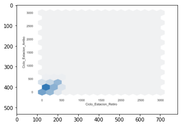

```python
%pylab inline
import matplotlib.image as mpimg
img = mpimg.imread('foto.png')
imgplot = plt.imshow(img)
plt.show()
```